# All Life Bank Customer Segmentation

## Insights (K_Means)

- **Cluster 0**:
  - Avg credit Limit: Low
  - Total Credit Cards: Low
  - Total Visits to banks: Low
  - Total Visits to Online: Low
  - Total Calls Made: Low
- **Cluster 1**:
  - Avg credit Limit: Low
  - Total Credit Cards: Moderate
  - Total Visits to banks: Moderate
  - Total Visits to Online: Low
  - Total Calls Made: Moderate
- **Cluster 2**:
  - Avg credit Limit: High
  - Total Credit Cards: High
  - Total Visits to banks: Moderate
  - Total Visits to Online: High
  - Total Calls Made: Moderate

### Hierarchical Clustering

```python
# list of distance metrics
distance_metrics = ["euclidean", "chebyshev", "mahalanobis", "cityblock"]

# list of linkage methods
linkage_methods = ["single", "complete", "average", "weighted"]

high_cophenet_corr = 0
high_dm_lm = [0, 0]

for dm in distance_metrics:
    for lm in linkage_methods:
        Z = linkage(subset_scaled_df, metric=dm, method=lm)
        c, coph_dists = cophenet(Z, pdist(subset_scaled_df))
        print(
            "Cophenetic correlation for {} distance and {} linkage is {}.".format(
                dm.capitalize(), lm, c
            )
        )
        if high_cophenet_corr < c:
            high_cophenet_corr = c
            high_dm_lm[0] = dm
            high_dm_lm[1] = lm
```

```
Cophenetic correlation for Euclidean distance and single linkage is 0.8788676940541079.
Cophenetic correlation for Euclidean distance and complete linkage is 0.8860521900934342.
Cophenetic correlation for Euclidean distance and average linkage is 0.9168725782090766.
Cophenetic correlation for Euclidean distance and weighted linkage is 0.9133393931042242.
Cophenetic correlation for Chebyshev distance and single linkage is 0.8978014062578786.
Cophenetic correlation for Chebyshev distance and complete linkage is 0.8623270916886306.
Cophenetic correlation for Chebyshev distance and average linkage is 0.9160784250471772.
Cophenetic correlation for Chebyshev distance and weighted linkage is 0.9109044268579872.
Cophenetic correlation for Mahalanobis distance and single linkage is 0.8959952526724227.
Cophenetic correlation for Mahalanobis distance and complete linkage is 0.6550023123197868.
Cophenetic correlation for Mahalanobis distance and average linkage is 0.8467618899578886.
Cophenetic correlation for Mahalanobis distance and weighted linkage is 0.8207917162822879.
Cophenetic correlation for Cityblock distance and single linkage is 0.8406488764445825.
Cophenetic correlation for Cityblock distance and complete linkage is 0.8890360877047411.
Cophenetic correlation for Cityblock distance and average linkage is 0.9149250127652871.
Cophenetic correlation for Cityblock distance and weighted linkage is 0.8901622514742297.
```

```python
# printing the combination of distance metric and linkage method with the highest cophenetic correlation
print(
    "Highest cophenetic correlation is {}, which is obtained with {} distance and {} linkage.".format(
        high_cophenet_corr, high_dm_lm[0].capitalize(), high_dm_lm[1]
    )
)
```

```
Highest cophenetic correlation is 0.9168725782090766, which is obtained with Euclidean distance and average linkage.
```

```python
# list of linkage methods
linkage_methods = ["single", "complete", "average", "centroid", "ward", "weighted"]

high_cophenet_corr = 0
high_dm_lm = [0, 0]

for lm in linkage_methods:
    Z = linkage(subset_scaled_df, metric="euclidean", method=lm)
    c, coph_dists = cophenet(Z, pdist(subset_scaled_df))
    print("Cophenetic correlation for {} linkage is {}.".format(lm, c))
    if high_cophenet_corr < c:
        high_cophenet_corr = c
        high_dm_lm[0] = "euclidean"
        high_dm_lm[1] = lm
```

```
Cophenetic correlation for single linkage is 0.8788676940541079.
Cophenetic correlation for complete linkage is 0.8860521900934342.
Cophenetic correlation for average linkage is 0.9168725782090766.
Cophenetic correlation for centroid linkage is 0.9134704636213649.
Cophenetic correlation for ward linkage is 0.774233615737438.
Cophenetic correlation for weighted linkage is 0.9133393931042242.
```

```python
# printing the combination of distance metric and linkage method with the highest cophenetic correlation
print(
    "Highest cophenetic correlation is {}, which is obtained with {} linkage.".format(
        high_cophenet_corr, high_dm_lm[1]
    )
)
```

```
Highest cophenetic correlation is 0.9168725782090766, which is obtained with average linkage.
```

#### For the data the cophenetic correlation is maximum for average linkage

#### Plot dendrograms for different linkage methods

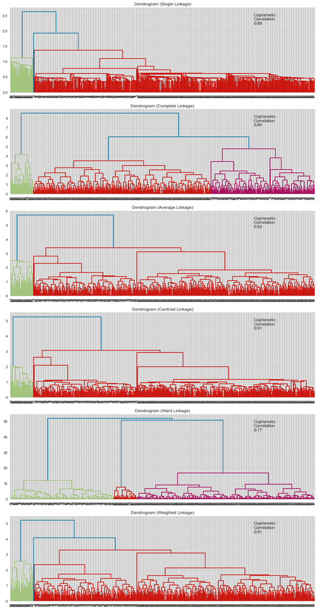

```python
# list of linkage methods
linkage_methods = ["single", "complete", "average", "centroid", "ward", "weighted"]

# lists to save results of cophenetic correlation calculation
compare_cols = ["Linkage", "Cophenetic Coefficient"]

# to create a subplot image
fig, axs = plt.subplots(len(linkage_methods), 1, figsize=(15, 30))

# We will enumerate through the list of linkage methods above
# For each linkage method, we will plot the dendrogram and calculate the cophenetic correlation
for i, method in enumerate(linkage_methods):
    Z = linkage(subset_scaled_df, metric="euclidean", method=method)

    dendrogram(Z, ax=axs[i])
    axs[i].set_title(f"Dendrogram ({method.capitalize()} Linkage)")

    coph_corr, coph_dist = cophenet(Z, pdist(subset_scaled_df))
    axs[i].annotate(
        f"Cophenetic\nCorrelation\n{coph_corr:0.2f}",
        (0.80, 0.80),
        xycoords="axes fraction",
    )
```

#### Observations

- The cophenetic correlation is highest (0.92) for average linkage method.
- But complete linkage has more distinct cluster and cophenetic correlation of 0.89
- 4 appears to be the appropriate number of clusters from the dendrogram for complete linkage.

```python
HCmodel = AgglomerativeClustering(n_clusters=4, affinity="euclidean", linkage="complete")
HCmodel.fit(subset_scaled_df)
```

```
AgglomerativeClustering(linkage='complete', n_clusters=4)
```

```python
subset_scaled_df["HC_Clusters"] = HCmodel.labels_
cusseg2["HC_Clusters"] = HCmodel.labels_
```